# Using the R package ‘bibliometrix’ for benchmark identification

Alfredo Sanchez-Tojar

09 April, 2019

The following collection of functions is a selected subset of all the functions explained in the vignettes of the R package `bibliometrix`:

https://cran.r-project.org/web/packages/bibliometrix/vignettes/bibliometrix-vignette.html

Bear in mind that the R package `bibliometrix` can currently deal with reference data extracted from: (1) Web of Science, (2) Scopus, (3) Cochrane, and (4) PubMed/MedLine (*Note: it should be possible to adjust it so that it can deal with data from other databases and search engines*).

Further information can be found in the official webpage: http://www.bibliometrix.org/

## 1.0 - Setting up and data preparation

### 1.1 - Load package

Loading the `bibliometrix`.

```r
pacman::p_load(bibliometrix)

# Clear memory
rm(list=ls())
```

### 1.2 - Load Data

Loading an exemplary database provided by the authors of `bibliometrix`, and converting the .bib file into a data frame.

```r
# importing some demo data
data <- readFiles("http://www.bibliometrix.org/datasets/savedrecs.bib")

# convert it to a dataframe
data.df <- convert2df(data, dbsource = "isi", format = "bibtex")
```

```
##
## Converting your isi collection into a bibliographic dataframe
##
## Articles extracted   100
## Articles extracted   200
## Articles extracted   291
## Done!
##
##
## Generating affiliation field tag AU_UN from C1:  Done!
```

## 2.0 - Analyzing bibliometric data

### 2.1 - Summary analysis

The function `biblioAnalysis()` allows to identify some interesting paremeters such as:

- Document types, which could be use to identify reviews.
- Most productive authors.
- Top manuscripts per citations.
- Most relevant sources.
- Most relevant keywords.

```r
# analyze data
results <- biblioAnalysis(data.df, sep = ";")

# print some summary results
summary(results)
```

```
##
##
## Main Information about data
##
##  Documents                             291
##  Sources (Journals, Books, etc.)       141
##  Keywords Plus (ID)                    463
##  Author's Keywords (DE)                339
##  Period                                1985 - 2015
##  Average citations per documents       11.73
##
##  Authors                               535
##  Author Appearances                    647
##  Authors of single-authored documents  121
##  Authors of multi-authored documents   414
##  Single-authored documents             144
##
##  Documents per Author                  0.544
##  Authors per Document                  1.84
##  Co-Authors per Documents              2.22
##  Collaboration Index                   2.82
##
##  Document types
##  ART EXHIBIT REVIEW              1
##  ARTICLE                         160
##  ARTICLE, PROCEEDINGS PAPER      7
##  BIOGRAPHICAL-ITEM               1
##  BOOK REVIEW                     32
##  CORRECTION, ADDITION            1
##  EDITORIAL MATERIAL              41
##  LETTER                          16
##  MEETING ABSTRACT                4
##  NOTE                            3
##  REVIEW                          25
##
##
## Annual Scientific Production
##
##  Year    Articles
##     1985        4
```

[output cut: 112 more lines]

```
##
##
## Most Relevant Keywords
##
##    Author Keywords (DE)      Articles Keywords-Plus (ID)     Articles
## 1      BIBLIOMETRICS               62    SCIENCE                   38
## 2      CITATION ANALYSIS           12    INDICATORS                24
## 3      SCIENTOMETRICS               7    IMPACT                    23
## 4      INFORMATION RETRIEVAL        6    CITATION ANALYSIS         18
## 5      H INDEX                      5    CITATION                  16
## 6      IMPACT FACTOR                5    H INDEX                   13
## 7      PEER REVIEW                  5    JOURNALS                  13
## 8      CITATIONS                    4    PUBLICATION               11
## 9      IMPACT FACTORS               4    GOOGLE SCHOLAR            10
## 10     NURSING                      4    INFORMATION SCIENCE       10
```

The results can additionally be plotted, which helps visualizing the most productive authors and countries, the annual scientific production, the average article citations/year, and the average total citations/year.

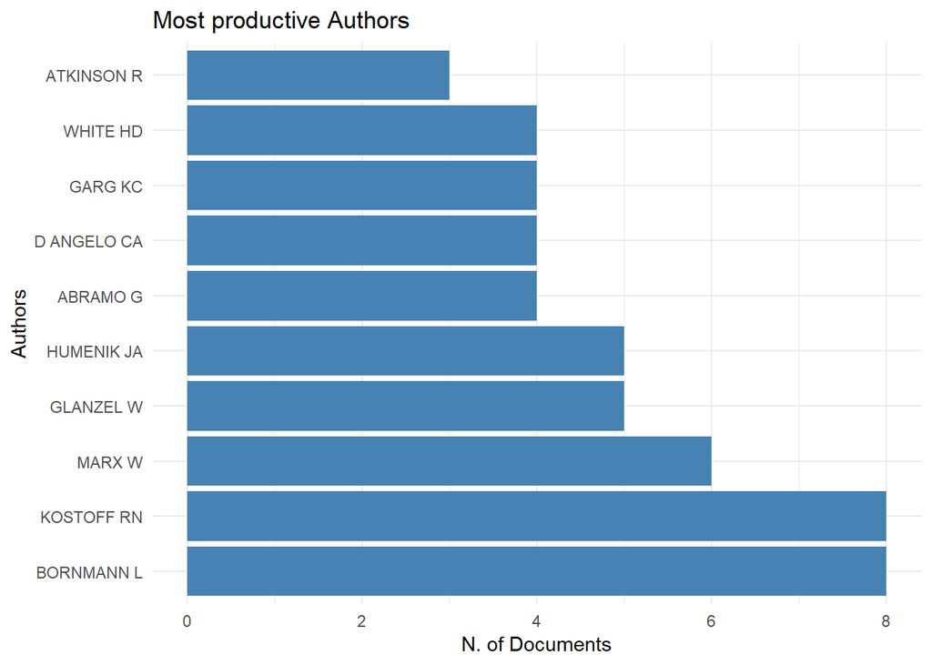

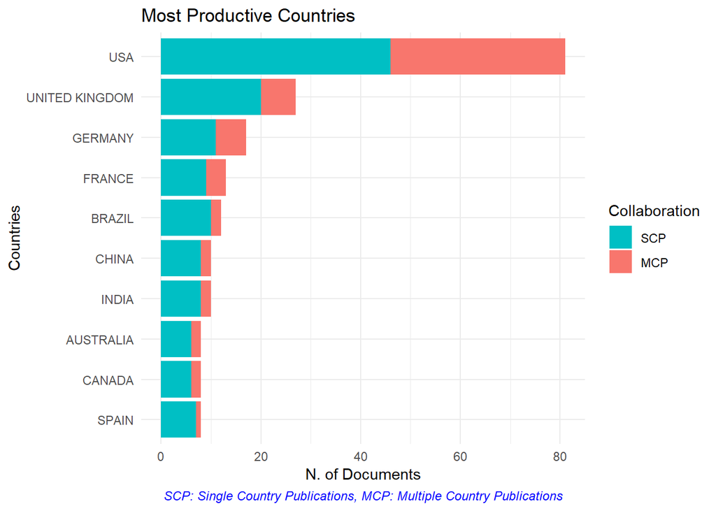

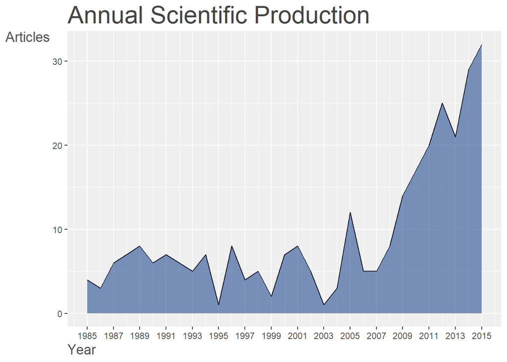

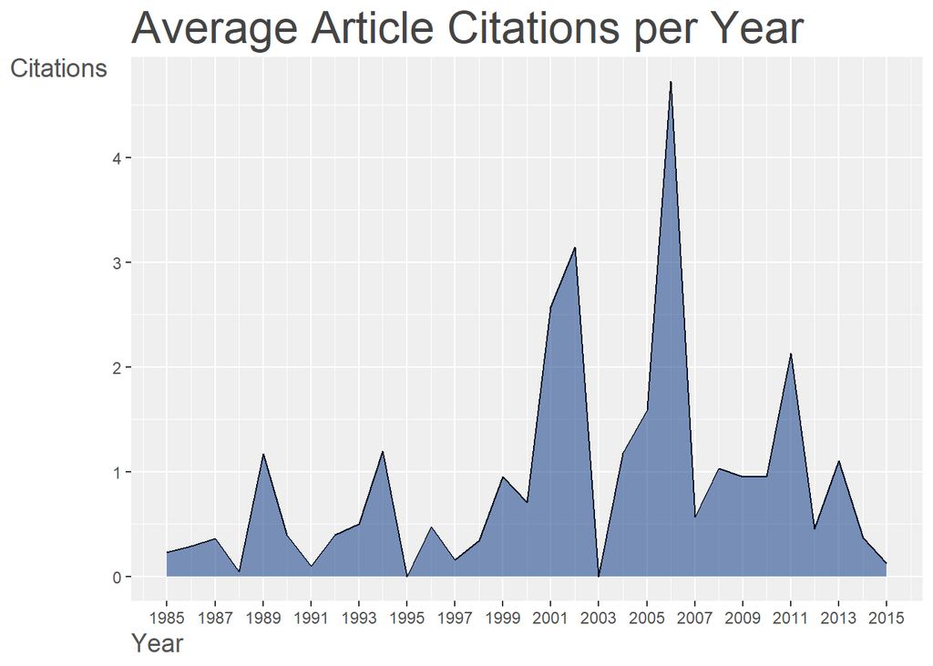

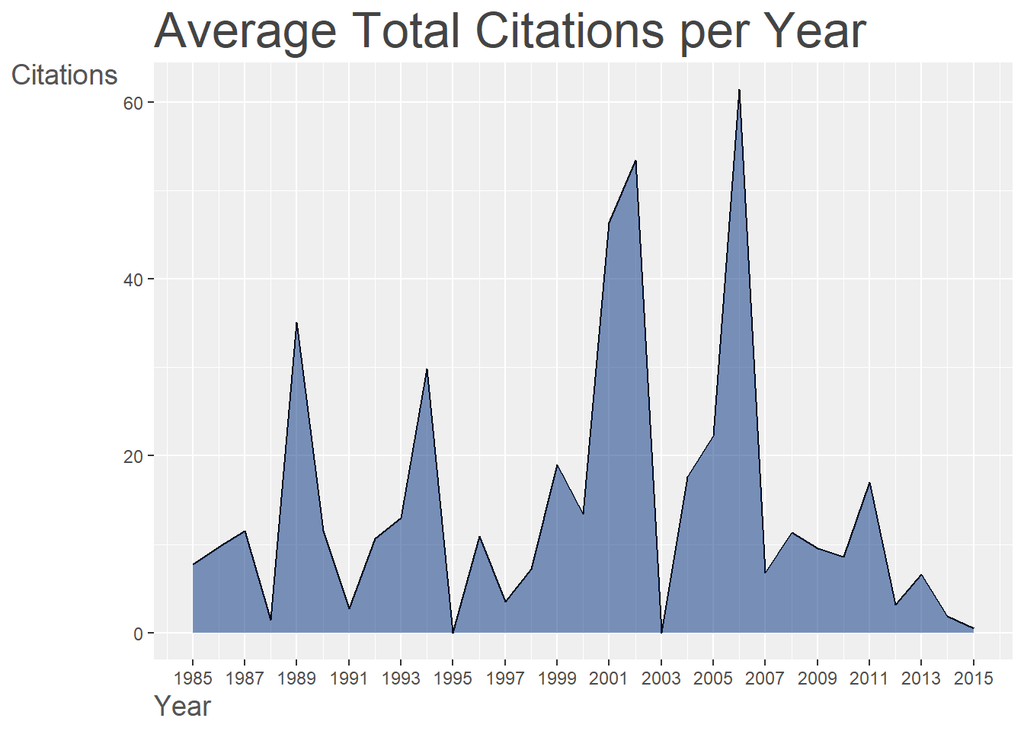

```r
plot(x = results)#, k = 10, pause = FALSE)
```

### 2.2 - What are the most cited papers?

```r
article.citations <- citations(data.df, field = "article", sep = ";")
cbind(article.citations$Cited[1:10])
```

```
##                                                                                  [,1]
## HIRSCH JE, 2005, P NATL ACAD SCI USA, V102, P16569, DOI 10.1073/PNAS.0507655102.   29
## SMALL H, 1973, J AM SOC INFORM SCI, V24, P265, DOI 10.1002/ASI.4630240406.         20
## PRITCHAR.A, 1969, J DOC, V25, P348.                                                17
## DE SOLLA PRICE DJ, 1963, LITTLE SCI BIG SCI.                                       16
## BRADFORD S. C, 1934, ENGINEERING-LONDON, V137, P85.                                13
## GARFIELD E, 2006, JAMA-J AM MED ASSOC, V295, P90, DOI 10.1001/JAMA.295.1.90.       12
## COLE FRANCIS J., 1917, SCI PROGR, V11, P578.                                       10
## DE BELLIS NICOLA, 2009, BIBLIOMETRICS CITATI.                                      10
## KESSLER MM, 1963, AM DOC, V14, P10, DOI 10.1002/ASI.5090140103.                    10
## MOED H. F., 2005, CITATION ANAL RES EV.                                            10
```

### 2.3 - Who are the most cited authors?

```r
author.citations <- citations(data.df, field = "author", sep = ";")
cbind(author.citations$Cited[1:20])
```

```
##               [,1]
## GARFIELD E     150
## BORNMANN L      92
## SMALL H         66
## CRONIN B        65
## WHITE HD        57
## GLANZEL W       50
## KOSTOFF RN      49
## EGGHE L         44
## LEYDESDORFF L   44
## NARIN F         43
## BROOKES BC      41
## MOED HF         37
## ANONYMOUS       34
## SCHUBERT A      34
## HIRSCH JE       33
## MCCAIN KW       27
## VAN RAAN AFJ    27
## MACROBERTS MH   25
## PRICE DJD       25
## SENGUPTA IN     23
```

*Note: consider how to deal with ANONYMOUS (see above)*

### 2.4. What are the most cited authors and articles within your database, i.e. when using only the citations from within the database?

This allows to estimate article and authors citations using exclusively the references contains withing the reference database imported. These citations counts *should* be use as complementary to the ones calculated above.

```r
local.citations <- localCitations(data.df, sep = ";")
```

```
## Articles analysed   100
## Articles analysed   200
## Articles analysed   202
```

```r
local.citations$Papers[1:10,]
```

```
##                                        Paper                              DOI Year LCS GCS
## 83      HOLDEN G, 2005, SOC WORK HEALTH CARE          10.1300/J010V41N03\\_01 2005   6  22
## 84    HOLDEN G, 2005, SOC WORK HEALTH CARE-a          10.1300/J010V41N03\\_03 2005   6  34
## 9           BROADUS RN, 1987, SCIENTOMETRICS               10.1007/BF02016680 1987   5  38
## 87  HOLDEN G, 2005, SOC WORK HEALTH CARE-a-b          10.1300/J010V41N03\\_09 2005   5   5
## 177            BORNMANN L, 2013, J INFORMETR        10.1016/J.JOI.2013.02.005 2013   5  10
## 178          BORNMANN L, 2013, J INFORMETR-a        10.1016/J.JOI.2012.09.003 2013   5  11
## 34                  SENGUPTA IN, 1992, LIBRI        10.1515/LIBR.1992.42.2.75 1992   4  20
## 59                     CRONIN B, 2000, J DOC         10.1108/EUM0000000007123 2000   4  20
## 103       SMITH DR, 2008, CONTACT DERMATITIS 10.1111/J.1600-0536.2008.01405.X 2008   4  11
## 114               ABRAMO G, 2009, RES POLICY     10.1016/J.RESPOL.2008.11.001 2009   4  43
```

```r
local.citations$Authors[1:20,]
```

```
##           Author LocalCitations
## 15      BARKER K             17
## 139     HOLDEN G             17
## 276  ROSENBERG G             17
## 1       ABRAMO G             12
## 61   D ANGELO CA             12
## 31    BORNMANN L             11
## 38    BROADUS RN              7
## 210       MARX W              5
## 300     SMITH DR              5
## 350   WILLIAMS R              5
## 47  CAPRASECCA A              4
## 58      CRONIN B              4
## 76    DI COSTA F              4
## 109      GARG KC              4
## 290  SENGUPTA IN              4
## 29    BORGMAN CL              3
## 69   DEBACKERE K              3
## 118    GLANZEL W              3
## 147   HUMENIK JA              3
## 173   KOSTOFF RN              3
```

### 2.3 - Other potentially useful functions from `bibliometrix`

#### 2.3.1. - Dominance factor

The function `dominance` calculates the authors’ dominance ranking as proposed by:

Kumar, S., & Kumar, S. 2008. Collaboration in research productivity in oil seed research institutes of India. In Proceedings of Fourth International Conference on Webometrics, Informetrics and Scientometrics.

The Dominance Factor is a ratio indicating the fraction of multi-authored articles in which a scholar appears as the first author.

```r
dominance.factor <- dominance(results)#, k = 10)
dominance.factor[1:10,]
```

```
##         Author Dominance Factor Tot Articles Single-Authored Multi-Authored First-Authored Rank by Articles Rank by DF
## 1   KOSTOFF RN        1.0000000            8               0              8              8                9          1
## 2     WHITE HD        1.0000000            4               3              1              1                3          1
## 3   BORGMAN CL        1.0000000            3               2              1              1                1          1
## 4     HOLDEN G        1.0000000            3               0              3              3                1          1
## 5   BORNMANN L        0.8333333            8               2              6              5                9          5
## 6     ABRAMO G        0.7500000            4               0              4              3                3          6
## 7      GARG KC        0.7500000            4               0              4              3                3          6
## 8    GLANZEL W        0.6000000            5               0              5              3                7          8
## 9  D ANGELO CA        0.2500000            4               0              4              1                3          9
## 10      MARX W        0.2000000            6               1              5              1                8         10
```

#### 2.3.2. - Lokta’s law

The function lotka estimates Lotka’s law coefficients for scientific productivity (Lotka A.J., 1926). Lotka’s law describes the frequency of publication by authors in any given field as an inverse square law, where the number of authors publishing a certain number of articles is a fixed ratio to the number of authors publishing a single article.

One can obtain an estimate of the author productivity.

```r
loktas <- lotka(results)
loktas$AuthorProd
```

```
##   N.Articles N.Authors        Freq
## 1          1       466 0.871028037
## 2          2        47 0.087850467
## 3          3        13 0.024299065
## 4          4         4 0.007476636
## 5          5         2 0.003738318
## 6          6         1 0.001869159
## 7          8         2 0.003738318
```

## 3.0 - Bibliographic network matrices

### 3.1. Bipartite networks:

#### 3.1.1. Publication networks

Bipartite networks can be used to observe the most relevant publication sources. `cocMatrix` estimates a rectangular binary matrix, representing a bipartite network where rows and columns are manuscripts and sources, respectively.

```r
bi.network <- cocMatrix(data.df, Field = "SO", sep = ";")
sort(Matrix::colSums(bi.network), decreasing = TRUE)[1:5]
```

```
##                                                         SCIENTOMETRICS
##                                                                     49
## JOURNAL OF THE AMERICAN SOCIETY FOR INFORMATION SCIENCE AND TECHNOLOGY
##                                                                     14
##                JOURNAL OF THE AMERICAN SOCIETY FOR INFORMATION SCIENCE
##                                                                      8
##                                                JOURNAL OF INFORMETRICS
##                                                                      6
##                                               JOURNAL OF DOCUMENTATION
##                                                                      6
```

#### 3.1.2. Citation networks

```r
bi.network.cit <- cocMatrix(data.df, Field = "CR", sep = ".  ")
sort(Matrix::colSums(bi.network.cit), decreasing = TRUE)[1:5]
```

```
##                                                                    KOSTOFF RN 1998 SCIENTOMETRICS
##                                                                                                  5
## CRONIN B 2014 BEYOND BIBLIOMETRICS: HARNESSING MULTIDIMENSIONAL INDICATORS OF SCHOLARLY IMPACT P3.
##                                                                                                  4
##                                                                            GARFIELD E 1963 AM DOC
##                                                                                                  4
##                                                           BORGMAN C. L. 1990 SCHOLARLY COMMUNICAT.
##                                                                                                  4
##                                                                HIRSCH JE 2005 P NATL ACAD SCI USA
##                                                                                                  3
```

#### 3.1.3. Author networks

```r
bi.network.aut <- cocMatrix(data.df, Field = "AU", sep = ".  ")
cbind(sort(Matrix::colSums(bi.network.aut), decreasing = TRUE)[1:20])
```

```
##                                [,1]
## ATKINSON R                        3
## WHITE HD                          3
## HOLDEN G,ROSENBERG G,BARKER K     3
## CRONIN B                          3
## BROADUS RN                        3
## ZITT M                            2
## BORNMANN L,MARX W                 2
## PRATHAP G                         2
## ADAMS J                           2
## BORNMANN L                        2
## MUNOZ PEREZ F                     2
## MOPPETT IK,HARDMAN JG             2
## PAGEL PS,HUDETZ JA                2
## THELWALL M                        2
## OPPENHEIM C                       2
## KOSTOFF RN,TSHITEYA R,PFEIL KM    2
## BORGMAN CL                        2
## DING Y                            2
## MCCAIN KW                         2
## OSAREH F                          2
```

#### 3.1.4. Author keyword networks

```r
bi.network.key <- cocMatrix(data.df, Field = "DE", sep = ".  ")
cbind(sort(Matrix::colSums(bi.network.key), decreasing = TRUE)[1:10])
```

```
##                                                                               [,1]
## SALT LAKE RESOURCE R\\&D, BIBLIOMETRICS, CO-AUTHORSHIP                           1
## BENCHMARKING, RESEARCH IMPACT, RESEARCH PRODUCTIVITY                             1
## SCENARIO TECHNIQUE, BIBLIOMETRICS, METHOD COMBINATION                            1
## EMERGING INDUSTRY, TECHNOLOGY ROADMAP, BIBLIOMETRICS                             1
## HYBRID ELECTRIC VEHICLES, ENERGY MANAGEMENT STRATEGY, BIBLIOMETRICS              1
## BIBLIOMETRICS, HISTORY, LAWS                                                     1
## CITATION ANALYSIS                                                                1
## RECOMMENDER SYSTEMS, ITEM QUALITY, FUZZY LINGUISTIC MODELING                     1
## F1000, BIBLIOMETRICS, CITING-SIDE INDICATOR                                      1
## BIBLIOMETRICS-AIDED RETRIEVAL, SUBJECT DELINEATION, COMPLEX SEARCH STRATEGIES    1
```

#### 3.1.5. Keyword plus networks

```r
bi.network.key.plus <- cocMatrix(data.df, Field = "ID", sep = ".  ")
cbind(sort(Matrix::colSums(bi.network.key.plus), decreasing = TRUE)[1:10])
```

```
##                                                                             [,1]
## INDICATORS                                                                     3
## CITATION                                                                       3
## SCIENCE                                                                        2
## IMPACT FACTORS, SCIENCE, WEB                                                   1
## ART                                                                            1
## BRINE                                                                          1
## PATENT INFORMATION, SOLAR-CELLS, INTELLIGENCE                                  1
## JOURNAL IMPACT FACTOR, INTERNATIONAL JOURNALS, CITATION ANALYSIS               1
## DETECTING RESEARCH FRONTS, EMERGING RESEARCH FRONTS, SCIENCE-AND-TECHNOLOGY    1
## FORECASTING EMERGING TECHNOLOGIES, DATABASE TOMOGRAPHY, DISCOVERY LRD          1
```

### 3.2. Bibliographic coupling

Two articles are said to be bibliographically coupled if at least one cited source appears in the bibliographies or reference lists of both articles (Kessler, 1963). The function `biblioNetwork` calculates, starting from a bibliographic data frame, the most frequently used coupling networks: Authors, Sources, and Countries.

#### 3.2.1. Article coupling

Articles with only a few references tend to be more weakly bibliographically coupled, if coupling strength is measured simply according to the number of references that articles contain in common.

```r
NetMatrix.article <- biblioNetwork(data.df, analysis = "coupling", network = "references", sep = ".  ")

# # general network summary stats
# netstat.article <- networkStat(NetMatrix.article)
```

#### 3.2.2. Author coupling

It might be more practical to switch to a relative measure of bibliographic coupling. The `normalizeSimilarity` function calculates Association strength, Inclusion, Jaccard or Salton similarity among vertices of a network. `normalizeSimilarity` can be recalled directly from the `networkPlot` function.

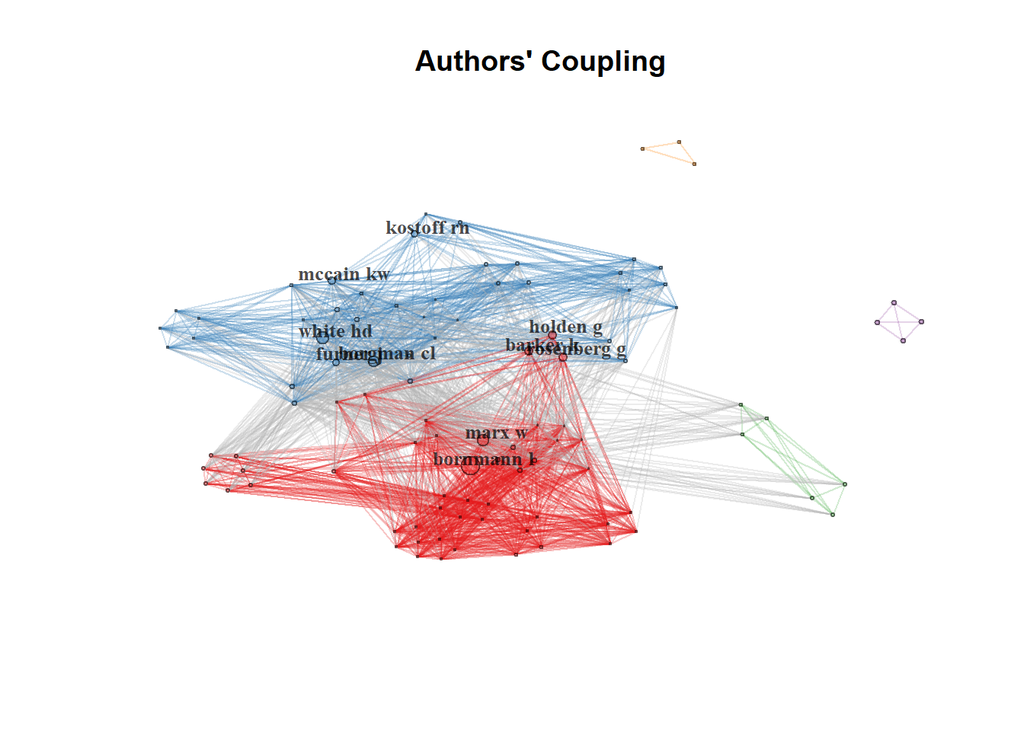

```r
NetMatrix.author <- biblioNetwork(data.df, analysis = "coupling", network = "authors", sep = ";")

# # general network summary stats
# netstat.author <- networkStat(NetMatrix.author)

#plotting
net=networkPlot(NetMatrix.author,  normalize = "salton", weighted=NULL, n = 100, Title = "Authors' Coupling", type = "fruchterman", size=5,size.cex=T,remove.multiple=TRUE,labelsize=0.8,label.n=10,label.cex=F)
```

### 3.3. Bibliographic co-citation

Co-citation happens when two articles are cited in a third article.

```r
cocitation <- biblioNetwork(data.df, analysis = "co-citation", network = "references", sep = ".  ")

# general network summary stats
netstat.cocitation <- networkStat(cocitation)
```

### 3.4. Bibliographic co-occurence

```r
NetMatrix.cooccurence <- biblioNetwork(data.df, analysis = "co-occurrences", network = "keywords", sep = ";")

# general network summary stats
netstat.cooccurence <- networkStat(NetMatrix.cooccurence)

summary(netstat.cooccurence)#, k=10)
```

```
##
##
## Main statistics about the network
##
##  Size                                  466
##  Density                               0.023
##  Transitivity                          0.324
##  Diameter                              5
##  Degree Centralization                 0.304
##  Average path length                   2.743
##
```